# Problem Set 5

Shaheer Abbasi

2023-02-21

## Set Up

```r
gapminder <- read_delim("gapminder.csv.bz2", show_col_types = FALSE)
```

There are 13055 rows in the data, and 25 columns.

```r
gapminder %>% sample_n(5) %>% gt()
```

| iso3 | name | iso2 | region | sub-region | intermediate-region | time | totalPopulation | fertilityRate | lifeExpectancy | childMortality | youthFemaleLiteracy | youthMaleLiteracy | adultLiteracy | GDP_PC | accessElectricity | agriculturalLand | agricultureTractors | cerealProduction | fertilizerHa | co2 | greenhouseGases | co2_PC | pm2.5_35 | battleDeaths |
| --- | --- | --- | --- | --- | --- | --- | --- | --- | --- | --- | --- | --- | --- | --- | --- | --- | --- | --- | --- | --- | --- | --- | --- | --- |
| HUN | Hungary | HU | Europe | Eastern Europe | NA | 1992 | 10369341 | 1.770 | 69.11707 | 15.8 | NA | NA | NA | 8601.4980 | 100.0000 | 61360 | 92000 | 10011896 | 39.85660 | 60395.490 | 79814.7970 | 5.82443 | NA | NA |
| ATG | Antigua and Barbuda | AG | Americas | Latin America and the Caribbean | Caribbean | 2001 | 77212 | 2.187 | 74.17100 | 15.1 | NA | NA | 98.95 | 12333.5816 | 97.6011 | 90 | NA | 51 | NA | 348.365 | 399.2652 | 4.51180 | NA | NA |
| BIH | Bosnia and Herzegovina | BA | Europe | Southern Europe | NA | 1964 | 3478997 | 3.515 | 62.81800 | NA | NA | NA | NA | NA | NA | NA | NA | NA | NA | NA | NA | NA | NA | NA |
| ETH | Ethiopia | ET | Africa | Sub-Saharan Africa | Eastern Africa | 1988 | 44757203 | 7.347 | 46.19400 | 208.4 | NA | NA | NA | 217.5104 | NA | 567750 | NA | 6136960 | 6.24324 | 2673.243 | 57246.2450 | 0.05973 | NA | NA |
| TJK | Tajikistan | TJ | Asia | Central Asia | NA | 1960 | 2087049 | 6.547 | 50.61300 | NA | NA | NA | NA | NA | NA | NA | NA | NA | NA | NA | NA | NA | NA | NA |

The data looks alright but it seems that there are lots of missing datapoints. Some variables are more impacted than others.

## Overview of Dataset

```r
#Assessing number of countries.
iso3_count <- n_distinct(gapminder$iso3)
name_count <- n_distinct(gapminder$name)
iso2_count <- n_distinct(gapminder$iso2)
```

It seems that there are around 249-253 countries in this dataset depending on if you are counting based on iso2 codes (249), iso3 codes (253), or names (250).

```r
iso2_name <- gapminder %>% group_by(iso2) %>% summarize(n = n_distinct(name)) %>% filter(n >= 2)

gapminder %>% filter(is.na(iso2)) %>% summarize(name = unique(name))
```

```
## # A tibble: 2 × 1
##   name
##   <chr>
## 1 <NA>
## 2 Namibia
```

It seems that there are two countries that do not have an iso2 code. As a result, they are treated as 1 additional country in the previous count that was conducted. Otherwise, there should not be any more overlapping iso2 codes.

Observations where there is no country name and Namibia both do not have ISO2 codes.

```r
gapminder %>% group_by(name) %>% summarize(iso2 = n_distinct(iso2), iso3 = n_distinct(iso3)) %>% filter(iso2 >= 2 | iso3 >= 2)
```

```
## # A tibble: 1 × 3
##   name   iso2  iso3
##   <chr> <int> <int>
## 1 <NA>      1     4
```

There are four unique ISO3 codes that have no country name associated with them.

```r
gapminder %>% filter(is.na(name)) %>% summarize(iso3 = unique(iso3))
```

```
## # A tibble: 4 × 1
##   iso3
##   <chr>
## 1 CHANISL
## 2 GBM
## 3 KOS
## 4 NLD_CURACAO
```

The ISO3 codes associated with no name countries are above.

```r
summary(gapminder$time)
```

```
##    Min. 1st Qu.  Median    Mean 3rd Qu.    Max.    NA's
##    1960    1975    1990    1990    2004    2019      36
```

The minimum time for the data is 1960 and the maximum time is 2019.

## C02 Emissions

```r
co2_pc_missing <- gapminder %>% filter (is.na(co2_PC)) %>% group_by(time) %>% summarize(co2_pc = n())
co2_missing <- gapminder %>% filter(is.na(co2)) %>% group_by(time) %>% summarize(co2 = n())

co2_missing <- co2_missing %>% left_join(x = co2_missing, y = co2_pc_missing, by = "time")

co2_missing %>% sample_n(5)
```

```
## # A tibble: 5 × 3
##    time   co2 co2_pc
##   <dbl> <int>  <int>
## 1  1969    51     51
## 2  1960    60     60
## 3  2018   217    217
## 4  2008    13     13
## 5  1989    48     48
```

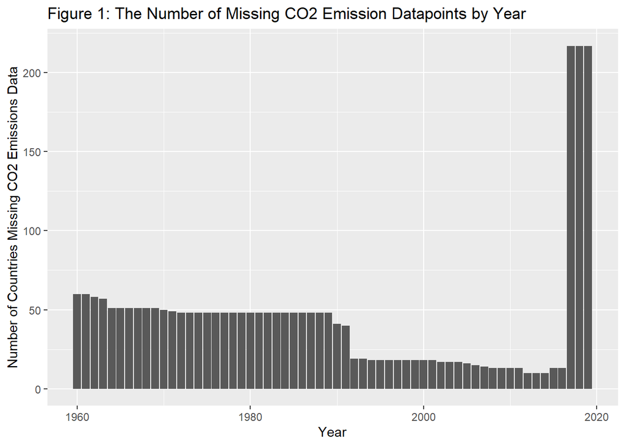

```r
ggplot(co2_missing, aes(x = time, y = co2)) + geom_col() + ggtitle("Figure 1: The Number of Missing CO2 Emission Datapoints by Year") + labs(y = "Number of Countries Missing CO2 Emissions Data", x = "Year")
```

The table above shows the number of countries missing CO2 Emissions data year by year. There is minimal difference between missing CO2 and CO2 Per Capital data, as a result, I only graph CO2 Emissions.

The graph shows the number of countries missing CO2 Emissions Data year on year. As seen, there is a spike in 2017-2019. Those are the years with the most missing data.

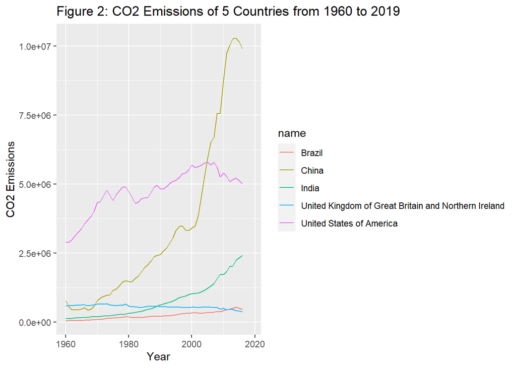

```r
gapminder %>%
  filter(iso3 == "USA" | iso3 == "CHN" | iso3 == "IND" | iso3 == "GBR" | iso3 == "BRA") %>%
  ggplot(aes(x = time, y = co2, color = name)) + geom_line() +
  ggtitle("Figure 2: CO2 Emissions of 5 Countries from 1960 to 2019") + labs(x = "Year", y = "CO2 Emissions")
```

##### United States

The United States maintains an incredibly high amount of emissions year on year, but is eventually overtaken by China in the early 2000s.

##### China

China experiences a massive jump in emissions after the 2000s that eventually starts slowing down in the late 2010s.

##### India and Brazil

Both India and Brazil experience a slow increase in emissions, with Indian emissions rising slightly faster than Brazilian ones. China and India’s rise in emissions track alongside their economic expansion.

##### United Kingdom

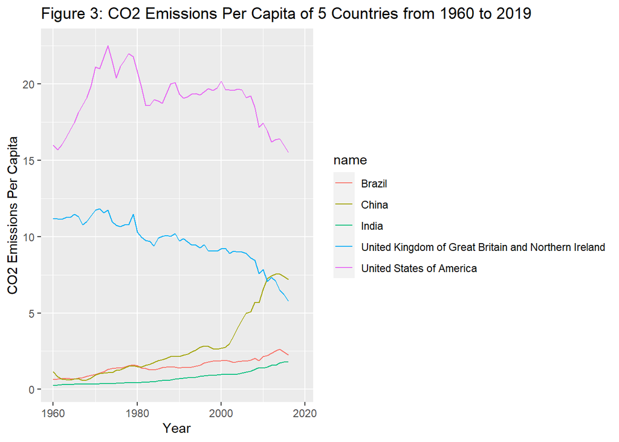

```r
gapminder %>%
  filter(iso3 == "USA" | iso3 == "CHN" | iso3 == "IND" | iso3 == "GBR" | iso3 == "BRA") %>%
  ggplot(aes(x = time, y = co2_PC, color = name)) + geom_line() +
  ggtitle("Figure 3: CO2 Emissions Per Capita of 5 Countries from 1960 to 2019") + labs(x = "Year", y = "CO2 Emissions Per Capita")
```

##### United States

The United States maintains dominance in this graph regarding emissions per capita. In the per-capita context, China does not overtake the United States.

##### United Kingdom

the United Kingdom also has very high emissions, being the second highest fora very long period of time in terms of per-capita emissions. Both the United States and Great Britain experience a decline in emissions per capita.

##### China

China also experiences are a large rise in emissions per capita, but it does not over take the United States. It does overtake the United Kingdom. The rise is not nearly as large as it when emissions are not per capita.

##### India and Brazil

Indian and Brazilian emissions per capita are also rising in this graph, but not nearly at the rate as they are when emissions are not per capita and they are both trending much more closely.

```r
co2_region <- gapminder %>% group_by(time, region) %>% filter(!is.na(co2_PC) & !is.na(region)) %>%
  summarize(avg_co2_pc = mean(co2_PC))
head(co2_region, 5)
```

```
## # A tibble: 5 × 3
## # Groups:   time [1]
##    time region   avg_co2_pc
##   <dbl> <chr>         <dbl>
## 1  1960 Africa        0.291
## 2  1960 Americas      7.15
## 3  1960 Asia          1.74
## 4  1960 Europe        5.77
## 5  1960 Oceania       2.73
```

```r
tail(co2_region, 5)
```

```
## # A tibble: 5 × 3
## # Groups:   time [1]
##    time region   avg_co2_pc
##   <dbl> <chr>         <dbl>
## 1  2016 Africa         1.20
## 2  2016 Americas       4.80
## 3  2016 Asia           6.47
## 4  2016 Europe         6.64
## 5  2016 Oceania        4.57
```

There is an increase in average emissions per capita in all regions other than the Americas where it decreases.

Asia and Europe reach parity in emissions per capita by 2016. In 1960, emissions per capita were much lower in Asia than Europe.

Emissions per capita increase drastically in Africa and Oceania.

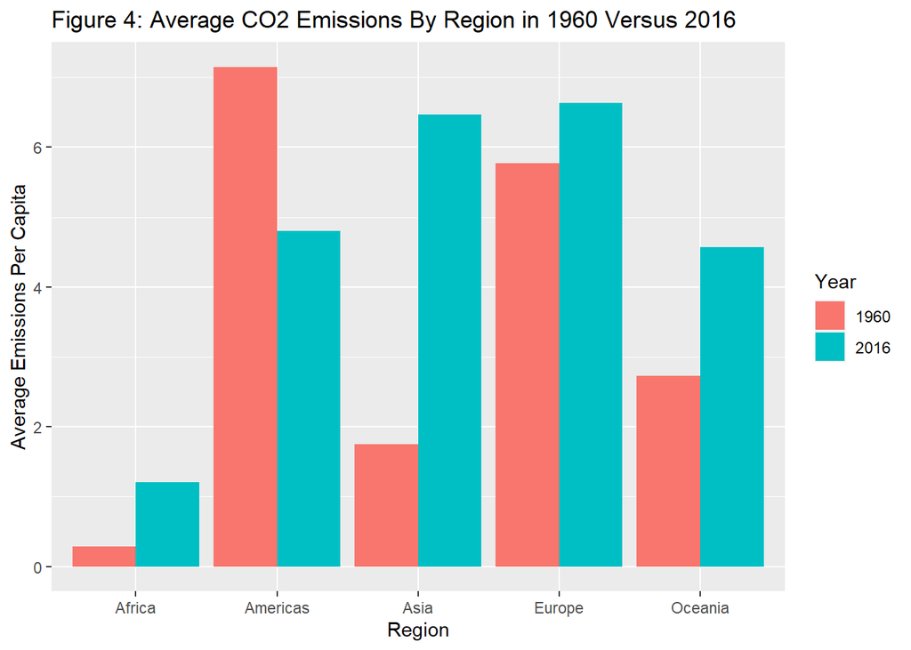

```r
edges_co2_region <- co2_region %>% filter(time == 1960 | time == 2016)

ggplot(data = edges_co2_region, aes(x = region, y= avg_co2_pc, fill = as.character(time))) +
  geom_col(position = "dodge") + ggtitle ("Figure 4: Average CO2 Emissions By Region in 1960 Versus 2016") + labs(x = "Region", y = "Average Emissions Per Capita", fill = "Year")
```

```r
top <- gapminder %>% filter (time == 2016 & !is.na(name))%>% group_by(region) %>%
  top_n(n = 3, wt = co2_PC) %>% ungroup()

bottom <- gapminder %>% filter (time == 2016 & !is.na(name)) %>% group_by(region) %>%
  top_n(n = -3, wt = co2_PC) %>% ungroup()

top_bottom <- rbind(top, bottom)

top_bottom %>% select(name, region, co2_PC) %>% group_by(region) %>%
  arrange(desc(co2_PC), .by_group = TRUE) %>% gt()
```

| name | co2_PC |
| --- | --- |
| Africa |  |
| South Africa | 8.48006 |
| Libya | 7.78851 |
| Seychelles | 6.39073 |
| Burundi | 0.04720 |
| Somalia | 0.04550 |
| Congo, Democratic Republic of the | 0.02564 |
| Americas |  |
| Trinidad and Tobago | 31.84485 |
| United States of America | 15.50220 |
| Canada | 15.09006 |
| Honduras | 1.05847 |
| Nicaragua | 0.88709 |
| Haiti | 0.27469 |
| Asia |  |
| Qatar | 38.90147 |
| Kuwait | 24.95251 |
| Bahrain | 22.22898 |
| Yemen | 0.39048 |
| Nepal | 0.33400 |
| Afghanistan | 0.24510 |
| Europe |  |
| Gibraltar | 18.80401 |
| Luxembourg | 15.44261 |
| Faroe Islands | 13.09289 |
| Moldova, Republic of | 1.82554 |
| Albania | 1.57716 |
| Liechtenstein | 1.36327 |
| Oceania |  |
| New Caledonia | 19.26650 |
| Australia | 15.53922 |
| Palau | 12.61986 |
| Kiribati | 0.58659 |
| Vanuatu | 0.52700 |
| Solomon Islands | 0.27232 |

## GDP Per Capita

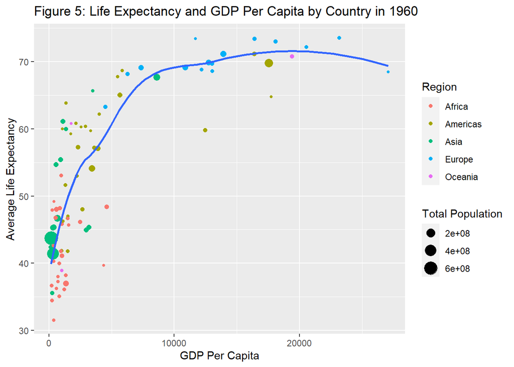

```r
gapminder %>% filter (time == 1960 & !is.na(GDP_PC) & !is.na(lifeExpectancy) & !is.na(name)) %>%
  ggplot(aes(x = GDP_PC, y = lifeExpectancy, color = region, size = totalPopulation)) +
  geom_point() + geom_smooth(aes(x = GDP_PC, y = lifeExpectancy),inherit.aes = FALSE, se = FALSE) +
  labs(y = "Average Life Expectancy", x = "GDP Per Capita", size = "Total Population", color = "Region") + ggtitle("Figure 5: Life Expectancy and GDP Per Capita by Country in 1960")
```

Based on the graph, marginal average life expectancy is very high when GDP per capita is very small. The gain in life expectancy for every increase in gdp per capita starts to get smaller and smaller the richer a country is.

It also seems that more countries in Africa and Asia have lower average life expectancy and GDP per capita while European countries are the opposite. A similar trend exists with population size. Countries with larger populations are those with lower GDP per capita and average life expectancy.

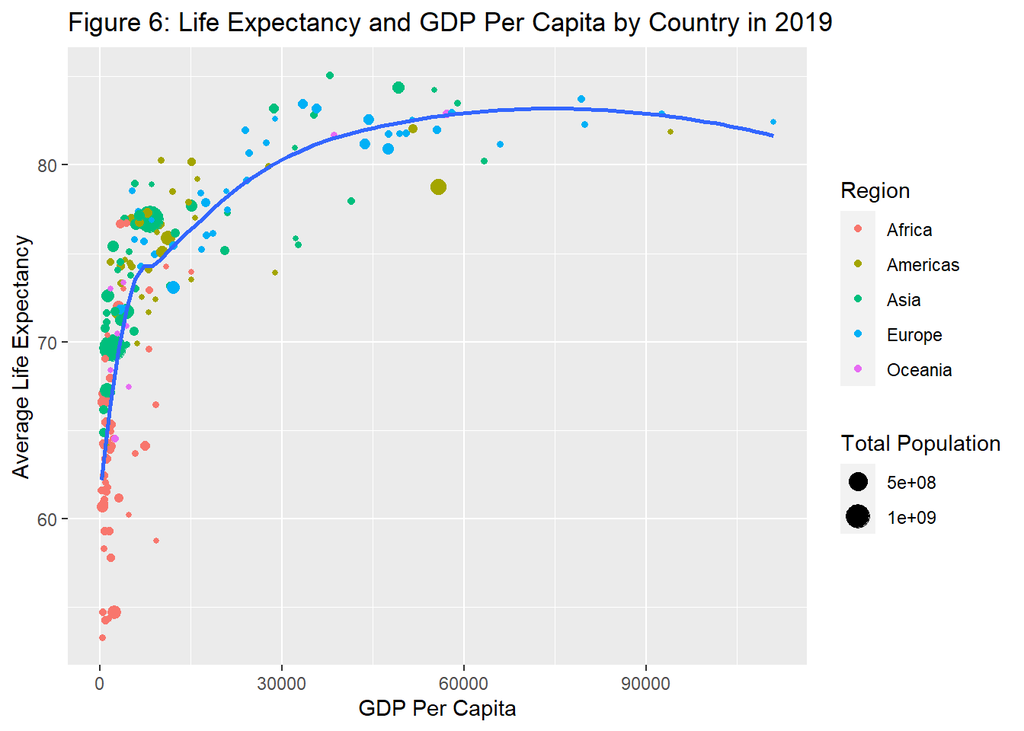

```r
gapminder %>% filter (time == 2019 & !is.na(GDP_PC) & !is.na(lifeExpectancy) & !is.na(name)) %>%
  ggplot(aes(x = GDP_PC, y = lifeExpectancy, color = region, size = totalPopulation)) +
  geom_point() + geom_smooth(aes(x = GDP_PC, y = lifeExpectancy),inherit.aes = FALSE, se = FALSE) +
  labs(y = "Average Life Expectancy", x = "GDP Per Capita", size = "Total Population", color = "Region") + ggtitle("Figure 6: Life Expectancy and GDP Per Capita by Country in 2019")
```

Compared to the data from 2019, life expectancy has increased drastically for many countries with the lowest life expectancy and gdp per capita. The countries that experienced these gains did not necessarily also experience an increase in gdp per capita. Even a slight increase in gdp per capita can drastically increase life expectancy, according to this 2019 data.

There are also more countries from the Americas and Asia in the higher life expectancy area. Also, most countries have larger populations.

This suggests that modern medical advancements have resulted in national wealth being a less important determinant for life expectancy than previously. Maybe this because important medical technology is now cheaper and has proliferated.

```r
gapminder %>% group_by(region, time) %>%
  filter (!is.na(lifeExpectancy) & (time == 1960 | time == 2019)) %>%
  summarize(avg_le = mean(lifeExpectancy)) %>%gt()
```

| time | avg_le |
| --- | --- |
| Africa |  |
| 1960 | 41.46600 |
| 2019 | 64.11014 |
| Americas |  |
| 1960 | 58.64651 |
| 2019 | 75.83206 |
| Asia |  |
| 1960 | 51.64931 |
| 2019 | 74.61739 |
| Europe |  |
| 1960 | 68.28254 |
| 2019 | 79.35714 |
| Oceania |  |
| 1960 | 56.39613 |
| 2019 | 73.52827 |
| NA |  |
| 1960 | 70.73900 |
| 2019 | 77.79056 |

The data corroborates the results seen in the graph. Life expectancy increases across the board. While it stays the highest in Europe, Asian average life expectancy rises quite a bit and reaches parity with Oceania and the Americas by the 2019.

```r
gapminder1 <- gapminder %>%
  filter (!is.na(lifeExpectancy) & (time == 1960 | time == 2019)) %>%
  mutate(le_growth = lifeExpectancy - lag(lifeExpectancy))

gapminder1 %>% filter(!is.na(le_growth) & time == 2019) %>%
  select(name, lifeExpectancy, le_growth) %>% arrange(desc(le_growth)) %>%
  head(10) %>% gt()
```

| name | lifeExpectancy | le_growth |
| --- | --- | --- |
| Maldives | 78.921 | 41.578 |
| Bhutan | 71.777 | 37.251 |
| Yemen | 66.125 | 36.206 |
| Timor-Leste | 69.495 | 35.766 |
| Nepal | 70.778 | 35.195 |
| Oman | 77.861 | 35.189 |
| Tunisia | 76.699 | 34.678 |
| China | 76.912 | 33.187 |
| Afghanistan | 64.833 | 32.387 |
| Turkey | 77.691 | 32.322 |

Shown are the countries in the data ranged with top 10 highest increase in life expectancy from 1960 to 2019. It seems that the countries with the greatest increase are in Asia. Many European countries are not high on this table because they already had a very high life expectancy, so the growth was smaller.

```r
gapminder2 <- gapminder %>%
  filter (!is.na(time) & !is.na(GDP_PC) & !is.na(region) & (time == 1960 | time == 2019)) %>%
  group_by(region, time) %>% summarize(avg_gdp_pc = mean(GDP_PC))
```

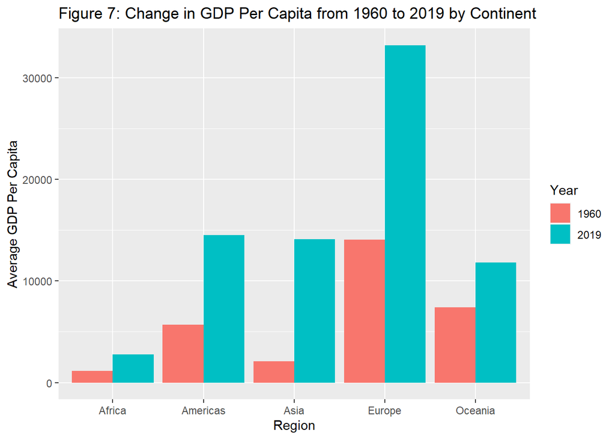

```r
ggplot(data = gapminder2, aes(x = region, y = avg_gdp_pc, fill = as.character(time))) +
  geom_col(position = "dodge") + labs (x = "Region", y = "Average GDP Per Capita", fill = "Year") +
  ggtitle("Figure 7: Change in GDP Per Capita from 1960 to 2019 by Continent")
```

```r
le_1960 <- gapminder %>% filter (time == 1960) %>% filter (!is.na(name) & !is.na(lifeExpectancy)) %>%
  arrange(desc(lifeExpectancy)) %>%
  mutate(rank = row_number())

le_19601 <- le_1960 %>% filter (iso3 == "USA") %>% select(time, rank)

le_2019 <- gapminder %>% filter (time == 2019 & !is.na(name)) %>% arrange(desc(lifeExpectancy)) %>%
  mutate(rank = row_number())

le_20191 <- le_2019 %>% filter (iso3 == "USA") %>% select(time, rank)

le_usa <- rbind(le_19601, le_20191)
le_usa
```

```
## # A tibble: 2 × 2
##    time  rank
##   <dbl> <int>
## 1  1960    17
## 2  2019    46
```

US ranking in life expectancy dropped from 17th to 46th highest life expectancy.

United States relative rank was 0.0904255 in 1960 and 0.2159624 in 2019.

**Conclusion**: The problem set itself took me 3-5 hours. I took another 2 hours trying to fix my rStudio because of the issue that kept causing it ot crash.